# R Notebook

# Introduction to ggplot2 homework

# Question 1.

Load in the libraries you need, and look at the backpack data. Take note of variable names and dimensions.

```r
library(tidyverse)
library(CodeClanData)
```

```r
backpack <- backpack
```

```r
names(backpack)
```

```
[1] "backpack_weight" "body_weight"     "ratio"           "back_problems"   "major"
[6] "year"            "sex"             "status"          "units"
```

```r
glimpse(backpack)
```

```
Rows: 100
Columns: 9
$ backpack_weight <int> 9, 8, 10, 6, 8, 5, 8, 4, 5, 2, 8, 21, 11, 11, 12, 11, 13, 6, 10, 5, 20, 14, …
$ body_weight     <int> 125, 195, 120, 155, 180, 240, 170, 185, 130, 120, 135, 160, 170, 170, 125, 1…
$ ratio           <dbl> 0.0720000, 0.0410256, 0.0833333, 0.0387097, 0.0444444, 0.0208333, 0.0470588,…
$ back_problems   <int> 1, 0, 1, 0, 0, 0, 0, 1, 0, 0, 0, 0, 0, 1, 1, 0, 1, 0, 1, 0, 0, 1, 0, 0, 0, 1…
$ major           <fct> Bio, Philosophy, GRC, CSC, EE, History, CM, ARCE, Bio, Bio, Bus, ME, CPE, CP…
$ year            <int> 3, 5, 4, 6, 2, 0, 3, 5, 4, 5, 3, 5, 4, 4, 3, 4, 4, 3, 3, 3, 2, 2, 5, 5, 3, 1…
$ sex             <fct> Female, Male, Female, Male, Female, Male, Male, Female, Female, Female, Fema…
$ status          <fct> U, U, U, G, U, G, U, U, U, U, U, U, U, U, U, U, U, U, U, U, U, U, U, U, U, U…
$ units           <int> 13, 12, 14, 0, 14, 0, 15, 18, 14, 8, 15, 12, 16, 16, 12, 16, 16, 16, 17, 14,…
```

# Question 2.

What is the distribution of backpack weights that students are carrying? Choose an appropriate graph to show the distribution.

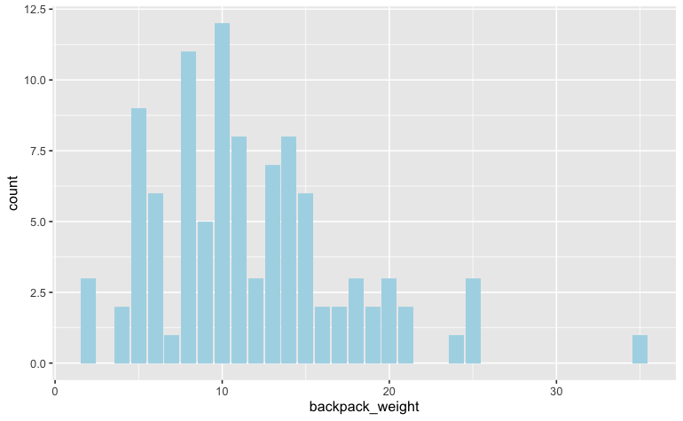

```r
ggplot(backpack) +
  geom_bar(aes(x = backpack_weight), fill = "light blue")
```

# Question 3.

Are there differences in backpack weight between sex?

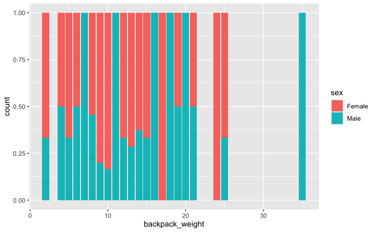

```r
ggplot(backpack) +
  geom_bar(aes(x = backpack_weight, fill = sex), position = "fill")
```

# Question 4.

What is the relationship between body weight and backpack weight?

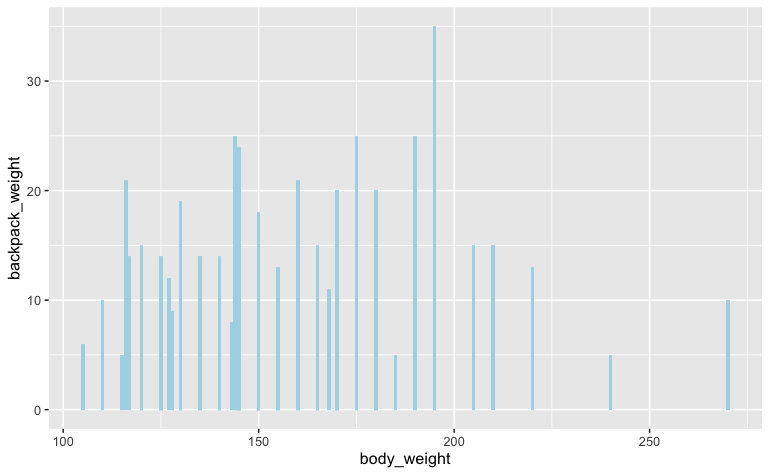

```r
ggplot(backpack) +
  geom_bar(aes(x = body_weight, y = backpack_weight), fill = "light blue", stat = "identity", position = "dodge")
```

```r
NA
NA
```

# Question 5.

Is this relationship different between men and women? Choose an appropriate plot and interpret your findings.

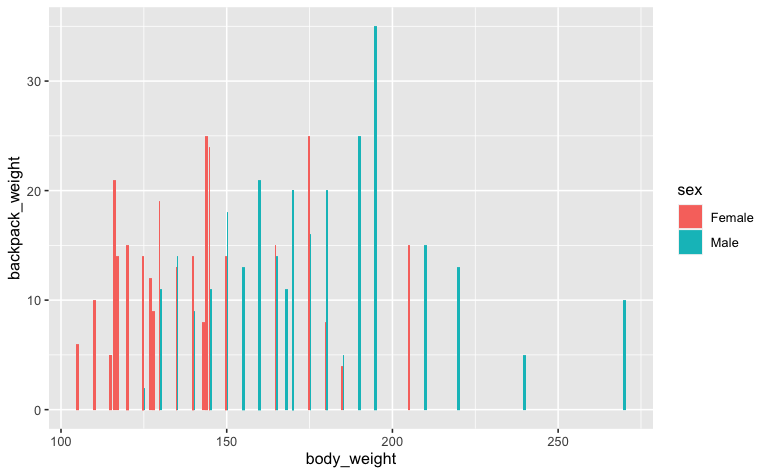

```r
ggplot(backpack) +
  geom_bar(aes(x = body_weight, y = backpack_weight, fill = sex), stat = "identity", position = "dodge")
```

From the results above you can see that as you get to the female weight of around 175 it drops off, whereas the males are almost 200 by the time the backpack weight drops, and is 10 heavier.

# Question 6.

What proportion of students report back pain?

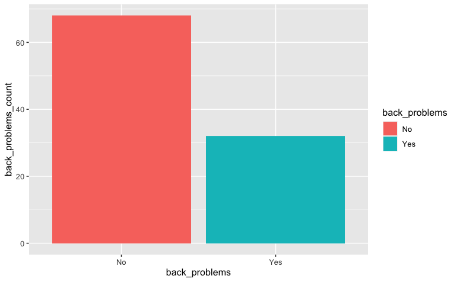

```r
back_problems <- backpack %>%
  mutate(back_problems = if_else(back_problems == "1", "Yes", "No")) %>%
  group_by(back_problems) %>%
  summarise(back_problems_count = n())
ggplot(back_problems) +
  geom_bar(aes(x = back_problems, y = back_problems_count, fill = back_problems), stat = "identity")
```

```r
NA
NA
```

# Question 7.

Is this proportion different between men and women?

```r
backpack %>%
  filter(back_problems == 1) %>%
  group_by(sex, back_problems) %>%
  summarise(back_problems = n())
```

| sex | back_problems |
| --- | --- |
| Female | 24 |
| Male | 8 |

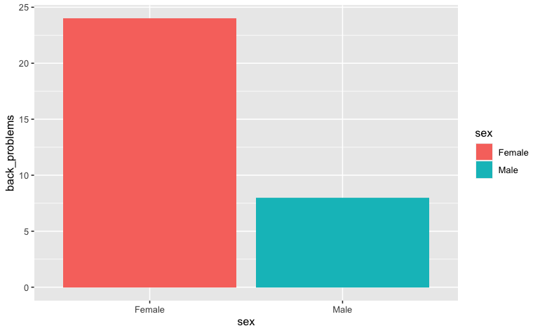

```r
backpack_back_problems <- backpack %>%
  filter(back_problems == 1) %>%
  group_by(sex) %>%
  summarise(back_problems = n())
ggplot(backpack_back_problems) +
  geom_bar(aes(x = sex, y = back_problems, fill = sex), stat = "identity")
```

```r
NA
NA
```

# Question 8.

Now you’ve investigated your data separately, create plots to describe the relationship between backpack weight, body weight, gender and reported backpain.

Try both backpack_weight and body_weight as well as the ratio.

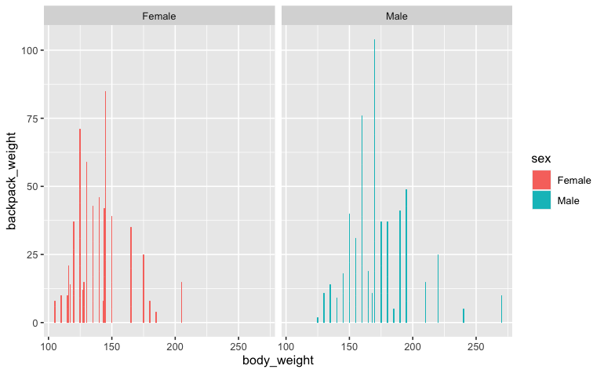

```r
ggplot(backpack) +
  geom_bar(aes(x = body_weight, y = backpack_weight, fill = sex), stat = "identity") +
  facet_wrap(~ sex)
```

From the graph, you can see that as the body weight in females reaches 150 and 170 for males, the backpack weight count reaches it’s maximum.

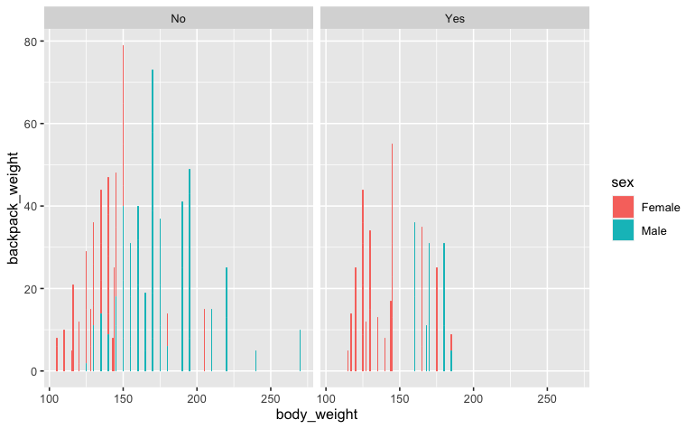

```r
backpack_updated <- backpack %>%
  mutate(back_problems = if_else(back_problems == "1", "Yes", "No"))

ggplot(backpack_updated) +
  geom_bar(aes(x = body_weight, y = backpack_weight, fill = sex), stat = "identity") +
  facet_wrap(~ back_problems)
```

The graph above shows there are more males who do not experience back pain.